# 資料型態與資料儲存方法

Ti-Ti Tung

July, 2018

## ———————————————————————————————–

# Install R

## ———————————————————————————————–

安裝 R 必須依使用者的作業系統來決定安裝的版本為何。 通常會安裝兩個部份：

- R 的主程式 (http://www.r-project.org/)
- R 的使用者介面 RStudio (http://www.rstudio.com)

先安裝主程式，再安裝 RStudio (事實上，R有非常多使用者介面可以選擇)

```
    下載玩R後，會有很多Packages，必須先載下來，再library進去才能使用
```

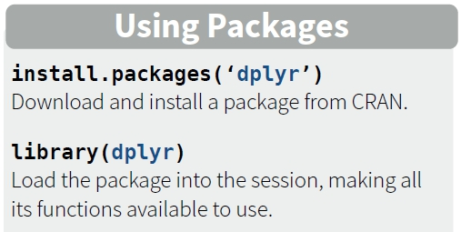

## ———————————————————————————————–

# Basic Data Types

## ———————————————————————————————–

> 口訣 : 把R當成Excel

```
  在R中，最基本的三種資料型態:

  -  「數字」的　numeric  (integer、double)
  -  「布林」的　logical  (TRUE、FALSE)
  -  「字串」的　character
```

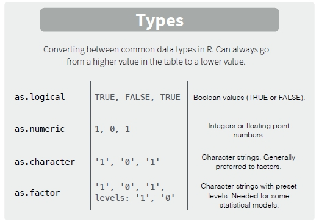

### 1. 利用 numeric 資料型態來進行四則運算

```r
# <- and = ，在R中都是等於的意思，可是一定要用 <- (快捷鍵:ALT + -)
# 因為這樣比較酷(我是認真的，這樣真的比較酷)

# integer(占的記憶體比較小)
# double (占的記憶體比較大)

#將值輸入Mike和Joe兩個variable之中
Mike <- 20
Joe  <- 20

Total_Age <- Joe + Mike

print(Total_Age)
```

```
## [1] 40
```

```r
# class()這個函數，可以知道變數的資料型態
class(Mike)
```

```
## [1] "numeric"
```

```r
class(Total_Age)
```

```
## [1] "numeric"
```

### 2. logic介紹與加減

- 布林值(Boolean)，只有兩個值 : TRUE、FALSE
- 布林值是**可以加減的**(TRUE = 1 and FALSE = 0)

```r
x <- TRUE
y <- FALSE

class(x)
```

```
## [1] "logical"
```

```r
## 任何邏輯判斷式的output都是布林值
1 < 2
```

```
## [1] TRUE
```

```r
1 > 2
```

```
## [1] FALSE
```

```r
## 布林值的運算
print(x + y)
```

```
## [1] 1
```

### 3. character介紹

- 口訣 : 跟Excel一模一樣的字串定義方法
- 只要用 “Taiwan” or ‘Taiwan’ 包起來的東西都是字串
- 通常都是用“Taiwan”，但在程式上需要，會有字串中還有字串的現象(" ‘Taiwan’ “)

```r
x <- "I love coffee"
y <- "I love tea"
class(x)
```

```
## [1] "character"
```

**小習題** : c()、paste0、str_c 差別在哪裡 - 利用length函數檢查output看看吧

```r
paste0(x,y)
```

```
## [1] "I love coffeeI love tea"
```

```r
str_c(x,y)
```

```
## [1] "I love coffeeI love tea"
```

```r
c(x,y)
```

```
## [1] "I love coffee" "I love tea"
```

字串的處理非常重要，之後再討論Text Mining時，會提到更深入地處理方式(正規表示法)。

## ———————————————————————————————–

# **資料儲存方式 – 向量**

## ———————————————————————————————–

## 1. vector :

請把R中所有的變數，都以向量當成儲存單位 :

- **使用口訣**:把每一個變數都當成excel中的**一行(A1:Z1)**
  - 如果只有A1有數字 : 長度為**1**的向量
  - 如果A1和B1有數字 : 長度為**2**的向量
- 向量具有同質性(homogeneous)
- R中建立向量的方式為 : c( )

**Creating Vectors**

```r
c(2, 4, 6)
```

```
## [1] 2 4 6
```

```r
1:10
```

```
##  [1]  1  2  3  4  5  6  7  8  9 10
```

```r
seq(2, 3, by=0.5)
```

```
## [1] 2.0 2.5 3.0
```

```r
# 長度為1的向量
x <- 100
# 長度為5的向量
y <- c(1, 2, 3 ,4 ,5 )

length(y)
```

```
## [1] 5
```

```r
# 向量可以疊加
z <- c(x,y)
print(z)
```

```
## [1] 100   1   2   3   4   5
```

```r
length(z)
```

```
## [1] 6
```

```r
# homogeneous
# 不論輸入什麼資料進去vector，都只有一種資料型態
class(z)
```

```
## [1] "numeric"
```

### 1.1. 試想，你常常在excel中做什麼樣的運算 :

- 整排同(+ - * /)一個數
- 整排做邏輯判斷
- 找兩個長度相同的column(兩條向量)來跑回歸(相關係數)

不覺得R跟excel的概念都是一樣的嗎?

```r
# 長度為20的向量
x <- 1:20

print(x)
```

```
##  [1]  1  2  3  4  5  6  7  8  9 10 11 12 13 14 15 16 17 18 19 20
```

```r
# 向量的四則運算都是整條同時進行
x*10
```

```
##  [1]  10  20  30  40  50  60  70  80  90 100 110 120 130 140 150 160 170
## [18] 180 190 200
```

```r
x > 10
```

```
##  [1] FALSE FALSE FALSE FALSE FALSE FALSE FALSE FALSE FALSE FALSE  TRUE
## [12]  TRUE  TRUE  TRUE  TRUE  TRUE  TRUE  TRUE  TRUE  TRUE
```

把布林值都加起來

```r
x_logic <- x > 10
# 整條布林值的四則運算
sum(x_logic)
```

```
## [1] 10
```

20個布林值的平均數

```r
# mean = excel中的average
mean(x_logic)
```

```
## [1] 0.5
```

```r
# 把布林值轉換成數字
x_logic*1
```

```
##  [1] 0 0 0 0 0 0 0 0 0 0 1 1 1 1 1 1 1 1 1 1
```

**相關係數**

```r
x <- 1:10
y <- c(1,4,5,6,8,3,7,10,12,13)
```

```r
print(x)
```

```
##  [1]  1  2  3  4  5  6  7  8  9 10
```

```r
print(y)
```

```
##  [1]  1  4  5  6  8  3  7 10 12 13
```

```r
# correlation test
cor.test(x,y)
```

```
##
##  Pearson's product-moment correlation
##
## data:  x and y
## t = 5.235, df = 8, p-value = 0.0007881
## alternative hypothesis: true correlation is not equal to 0
## 95 percent confidence interval:
##  0.5608523 0.9713505
## sample estimates:
##       cor
## 0.8797979
```

## 2. data.frame :

- data.frame，就是Excel的工作表
- vector只能包含一種資料型態，data.frame的column可想像成很多個vector串聯組成，如此一來就能包含多種資料型態(每個column – 一種資料型態)
- heterogeneous

```r
# 顯示前10個variable
# 每一個column有自己的資料型態

head(mpg, 10)
```

```
## # A tibble: 10 x 11
##    manufacturer model    displ  year   cyl trans   drv     cty   hwy fl
##    <chr>        <chr>    <dbl> <int> <int> <chr>   <chr> <int> <int> <chr>
##  1 audi         a4         1.8  1999     4 auto(l~ f        18    29 p
##  2 audi         a4         1.8  1999     4 manual~ f        21    29 p
##  3 audi         a4         2    2008     4 manual~ f        20    31 p
##  4 audi         a4         2    2008     4 auto(a~ f        21    30 p
##  5 audi         a4         2.8  1999     6 auto(l~ f        16    26 p
##  6 audi         a4         2.8  1999     6 manual~ f        18    26 p
##  7 audi         a4         3.1  2008     6 auto(a~ f        18    27 p
##  8 audi         a4 quat~   1.8  1999     4 manual~ 4        18    26 p
##  9 audi         a4 quat~   1.8  1999     4 auto(l~ 4        16    25 p
## 10 audi         a4 quat~   2    2008     4 manual~ 4        20    28 p
## # ... with 1 more variable: class <chr>
```

#### Example :

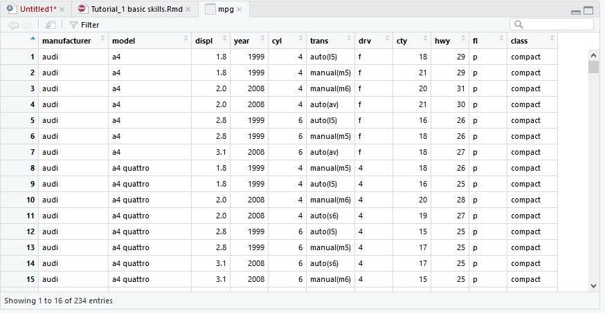

```r
# 了解資料
# Data column name
names(mpg)
```

```
##  [1] "manufacturer" "model"        "displ"        "year"
##  [5] "cyl"          "trans"        "drv"          "cty"
##  [9] "hwy"          "fl"           "class"
```

```r
# Data Stucture
str(mpg)
```

```
## Classes 'tbl_df', 'tbl' and 'data.frame':    234 obs. of  11 variables:
##  $ manufacturer: chr  "audi" "audi" "audi" "audi" ...
##  $ model       : chr  "a4" "a4" "a4" "a4" ...
##  $ displ       : num  1.8 1.8 2 2 2.8 2.8 3.1 1.8 1.8 2 ...
##  $ year        : int  1999 1999 2008 2008 1999 1999 2008 1999 1999 2008 ...
##  $ cyl         : int  4 4 4 4 6 6 6 4 4 4 ...
##  $ trans       : chr  "auto(l5)" "manual(m5)" "manual(m6)" "auto(av)" ...
##  $ drv         : chr  "f" "f" "f" "f" ...
##  $ cty         : int  18 21 20 21 16 18 18 18 16 20 ...
##  $ hwy         : int  29 29 31 30 26 26 27 26 25 28 ...
##  $ fl          : chr  "p" "p" "p" "p" ...
##  $ class       : chr  "compact" "compact" "compact" "compact" ...
```

```r
# Data summary
summary(mpg)
```

```
##  manufacturer          model               displ            year
##  Length:234         Length:234         Min.   :1.600   Min.   :1999
##  Class :character   Class :character   1st Qu.:2.400   1st Qu.:1999
##  Mode  :character   Mode  :character   Median :3.300   Median :2004
##                                        Mean   :3.472   Mean   :2004
##                                        3rd Qu.:4.600   3rd Qu.:2008
##                                        Max.   :7.000   Max.   :2008
##       cyl           trans               drv                 cty
##  Min.   :4.000   Length:234         Length:234         Min.   : 9.00
##  1st Qu.:4.000   Class :character   Class :character   1st Qu.:14.00
##  Median :6.000   Mode  :character   Mode  :character   Median :17.00
##  Mean   :5.889                                         Mean   :16.86
##  3rd Qu.:8.000                                         3rd Qu.:19.00
##  Max.   :8.000                                         Max.   :35.00
##       hwy             fl               class
##  Min.   :12.00   Length:234         Length:234
##  1st Qu.:18.00   Class :character   Class :character
##  Median :24.00   Mode  :character   Mode  :character
##  Mean   :23.44
##  3rd Qu.:27.00
##  Max.   :44.00
```

所有函數名稱都很直觀，當你有想用的函數時，可以嘗試去猜名稱

## 3. matrix :

```r
# 較無結構的矩陣，內容與dataframe一樣
A <- matrix(c(1:6),2,3)
#參教依序為資料、列數、行數，是否依列填入資料
show(A)
```

```
##      [,1] [,2] [,3]
## [1,]    1    3    5
## [2,]    2    4    6
```

```r
B <- matrix(c(1:6),2,3,byrow=TRUE)
#若byrow=true，則依列填入資料，預設為false
show(B)
```

```
##      [,1] [,2] [,3]
## [1,]    1    2    3
## [2,]    4    5    6
```

**3.1. 矩陣的運算 (1)**

```r
X1 <- matrix(c(1:4), nrow=2, ncol=2)
show(X1)
```

```
##      [,1] [,2]
## [1,]    1    3
## [2,]    2    4
```

```r
X1+1
```

```
##      [,1] [,2]
## [1,]    2    4
## [2,]    3    5
```

```r
X1^2
```

```
##      [,1] [,2]
## [1,]    1    9
## [2,]    4   16
```

**3.2. 矩陣的運算 (2): 轉置矩陣**

```r
X2 <- matrix(c(4:9),nrow=2, ncol=3)
show(X2)
```

```
##      [,1] [,2] [,3]
## [1,]    4    6    8
## [2,]    5    7    9
```

```r
t(X2)
```

```
##      [,1] [,2]
## [1,]    4    5
## [2,]    6    7
## [3,]    8    9
```

**3.3. 矩陣的運算 (3): 維度計算**

```r
dim(X2)
```

```
## [1] 2 3
```

```r
nrow(X2)
```

```
## [1] 2
```

```r
ncol(X2)
```

```
## [1] 3
```

**3.4. 矩陣的運算 (4): 反矩陣**

```r
X3 <- solve(X1) # inverse matrix
X1*X3 # 元素間相加
```

```
##      [,1] [,2]
## [1,]   -2  4.5
## [2,]    2 -2.0
```

```r
X1%*%X3  # 矩陣相乘
```

```
##      [,1] [,2]
## [1,]    1    0
## [2,]    0    1
```

**3.5. 矩陣的運算 (5): Joining Rows (Columns)**

```r
X1 <- matrix(c(1:6),nrow=2, ncol=3)
X2 <- matrix(c(4:9),nrow=2, ncol=3)
rbind(X1,X2)  #Joining Rows 矩陣合併
```

```
##      [,1] [,2] [,3]
## [1,]    1    3    5
## [2,]    2    4    6
## [3,]    4    6    8
## [4,]    5    7    9
```

```r
cbind(X1,X2)  #Joining Columns 矩陣合併
```

```
##      [,1] [,2] [,3] [,4] [,5] [,6]
## [1,]    1    3    5    4    6    8
## [2,]    2    4    6    5    7    9
```

**3.2 Data type transfer**

```r
A <- matrix(c(1:6),2,3)
colnames(A)=c("C1", "C2","C3")
B <- data.frame(A)
show(B)
```

```
##   C1 C2 C3
## 1  1  3  5
## 2  2  4  6
```

```r
show(B$C1)
```

```
## [1] 1 2
```

```r
str(B)
```

```
## 'data.frame':    2 obs. of  3 variables:
##  $ C1: int  1 2
##  $ C2: int  3 4
##  $ C3: int  5 6
```

## 4. list :

- list是R特有的資料儲存方式，屬於異質性的vector
- 一般的vector，一個位置就只能放一個值(numeric、logical、character)
- list的位置，能放任何東西(list、vector、data.frame)
- heterogeneous

```r
# 沒有標名子的list
x1 <- list(c(1, 2), c(3, 4))
x2 <- list(list(1, 2), list(3, 4))
x3 <- list(1, list(2, list(3)))
x1
```

```
## [[1]]
## [1] 1 2
##
## [[2]]
## [1] 3 4
```

```r
x2
```

```
## [[1]]
## [[1]][[1]]
## [1] 1
##
## [[1]][[2]]
## [1] 2
##
##
## [[2]]
## [[2]][[1]]
## [1] 3
##
## [[2]][[2]]
## [1] 4
```

```r
x3
```

```
## [[1]]
## [1] 1
##
## [[2]]
## [[2]][[1]]
## [1] 2
##
## [[2]][[2]]
## [[2]][[2]][[1]]
## [1] 3
```

#### I’ll draw them as follows::

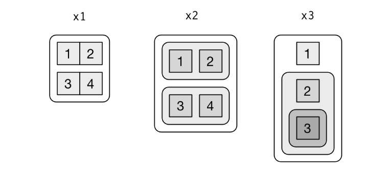

#### A list with title names::

```r
# 有標名子的list

Mike <- list(age = 20, gender = "male",
             drama = c("天龍八部","倚天屠龍記"),
             dataframe = head(mpg[,1:5]))

print(Mike)
```

```
## $age
## [1] 20
##
## $gender
## [1] "male"
##
## $drama
## [1] "天龍八部"   "倚天屠龍記"
##
## $dataframe
## # A tibble: 6 x 5
##   manufacturer model displ  year   cyl
##   <chr>        <chr> <dbl> <int> <int>
## 1 audi         a4      1.8  1999     4
## 2 audi         a4      1.8  1999     4
## 3 audi         a4      2    2008     4
## 4 audi         a4      2    2008     4
## 5 audi         a4      2.8  1999     6
## 6 audi         a4      2.8  1999     6
```

```r
str(Mike)
```

```
## List of 4
##  $ age      : num 20
##  $ gender   : chr "male"
##  $ drama    : chr [1:2] "天龍八部" "倚天屠龍記"
##  $ dataframe:Classes 'tbl_df', 'tbl' and 'data.frame':   6 obs. of  5 variables:
##   ..$ manufacturer: chr [1:6] "audi" "audi" "audi" "audi" ...
##   ..$ model       : chr [1:6] "a4" "a4" "a4" "a4" ...
##   ..$ displ       : num [1:6] 1.8 1.8 2 2 2.8 2.8
##   ..$ year        : int [1:6] 1999 1999 2008 2008 1999 1999
##   ..$ cyl         : int [1:6] 4 4 4 4 6 6
```

#### A list without title names::

```r
# 沒有標名子的list
# 他就用[[]] -- 標記順序

Mike <- list( 20,
              "male",
              c("天龍八部","倚天屠龍記"),
              head(mpg[,1:5]))
```

#### replace title names by [ [ ] ]::

```r
print(Mike[1:3])
```

```
## [[1]]
## [1] 20
##
## [[2]]
## [1] "male"
##
## [[3]]
## [1] "天龍八部"   "倚天屠龍記"
```

```r
str(Mike[1:3])
```

```
## List of 3
##  $ : num 20
##  $ : chr "male"
##  $ : chr [1:2] "天龍八部" "倚天屠龍記"
```

## ———————————————————————————————–

# 讀取資料元素

## ———————————————————————————————–

現在我們知道R是怎麼儲存資料了!那我們要怎麼把存好的資料取出來呢?這裡的讀去資料是指**subset**，並不只是觀察資料長什麼樣子，而是從一個大的Dataset中，讀取我們想要的部分就好

```
  本節目標 :

  -  怎麼讀取vector
  -  怎麼讀取data.frame (matrix)
  -  怎麼讀取list
```

**1. 所有形式括號的用途 :**

```r
# 用中括號來做讀取動作

"1.  [ ]   -- 用來選取"
"2. [[ ]]  -- 用來選取"

"3.  ( )   -- 用來建立vector"
"4.  { }    -- 用來包住Loop、if-else判斷式、Function"
```

**2. 用名子來讀取資料 :**

```r
"用 variable name + $ + title name 讀取資料"
```

### **vector**

```r
FGU_number <- c(1,0,3,1,3,3,2,1)

# 讀取vector中第 1 個字元
FGU_number[1]
```

```
## [1] 1
```

```r
# 讀取vector中第 3 個字元
FGU_number[3]
```

```
## [1] 3
```

### **data.frame**

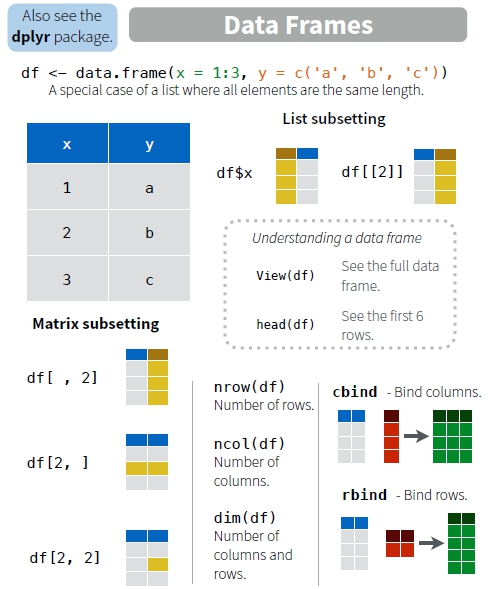

```r
test <- head(mpg,5)
print(test)
```

```
## # A tibble: 5 x 11
##   manufacturer model displ  year   cyl trans drv     cty   hwy fl    class
##   <chr>        <chr> <dbl> <int> <int> <chr> <chr> <int> <int> <chr> <chr>
## 1 audi         a4      1.8  1999     4 auto~ f        18    29 p     comp~
## 2 audi         a4      1.8  1999     4 manu~ f        21    29 p     comp~
## 3 audi         a4      2    2008     4 manu~ f        20    31 p     comp~
## 4 audi         a4      2    2008     4 auto~ f        21    30 p     comp~
## 5 audi         a4      2.8  1999     6 auto~ f        16    26 p     comp~
```

先讀**row**再讀**column**

```r
"data.frame[ (for row) , (for column) ]"
```

```r
# 讀第3條row
test[3,]
```

```
## # A tibble: 1 x 11
##   manufacturer model displ  year   cyl trans drv     cty   hwy fl    class
##   <chr>        <chr> <dbl> <int> <int> <chr> <chr> <int> <int> <chr> <chr>
## 1 audi         a4        2  2008     4 manu~ f        20    31 p     comp~
```

```r
# 讀第4條column(name = "year")
test[,4]
```

```
## # A tibble: 5 x 1
##    year
##   <int>
## 1  1999
## 2  1999
## 3  2008
## 4  2008
## 5  1999
```

```r
# 用title name來讀取
test[,"year"]
```

```
## # A tibble: 5 x 1
##    year
##   <int>
## 1  1999
## 2  1999
## 3  2008
## 4  2008
## 5  1999
```

**練習 : 讀取第4條column – “year”中的2008**

```r
# 先讀row再讀column
test[3,4]
```

```
## # A tibble: 1 x 1
##    year
##   <int>
## 1  2008
```

```r
# title name -- 一定要用 " " 括起來
test[3,"year"]
```

```
## # A tibble: 1 x 1
##    year
##   <int>
## 1  2008
```

- **test [ 3, year ]**

**練習 : 用錢符號讀取“year”中的2008**

```r
# 用 錢符號選取 ( $ )
test$year
```

```
## [1] 1999 1999 2008 2008 1999
```

```r
test$year[3]
```

```
## [1] 2008
```

**練習 : 用vector取值**

```r
# select by []

test[2:3,"year"]
```

```
## # A tibble: 2 x 1
##    year
##   <int>
## 1  1999
## 2  2008
```

```r
test[,c(1,5)]
```

```
## # A tibble: 5 x 2
##   manufacturer   cyl
##   <chr>        <int>
## 1 audi             4
## 2 audi             4
## 3 audi             4
## 4 audi             4
## 5 audi             6
```

**練習 : 用減號(-)來刪除**

```r
test[,-c(1:7)]
```

```
## # A tibble: 5 x 4
##     cty   hwy fl    class
##   <int> <int> <chr> <chr>
## 1    18    29 p     compact
## 2    21    29 p     compact
## 3    20    31 p     compact
## 4    21    30 p     compact
## 5    16    26 p     compact
```

##### **Important Practice :**

```
請問 test $ year 和 test [ , "year" ] 的差別
```

```r
# select by []
test[,"year"]
test[3,"year"]

# select by [[]]
test[["year"]]
test[["year"]][3]

# select by $
test$year
test$year[3]
```

## **list**

把list想像一輛列車，怎麼讀取列車中**不同節次**的東西我們已經會了(讀取vector or data.frame)。

因此我們只要，把想要的列車**節次**抓出來，在用一樣的方法讀取裡面的資料就行了唷

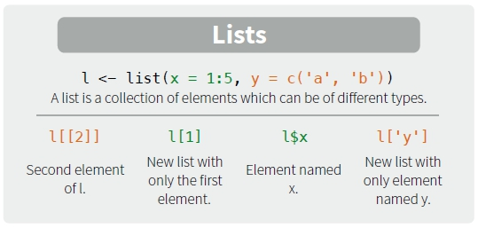

```r
Mike <- list(age = 20, gender = "male",
             drama = c("天龍八部","倚天屠龍記"),
             dataframe = head(mpg[1:5,1:5]))

print(Mike)
```

```
## $age
## [1] 20
##
## $gender
## [1] "male"
##
## $drama
## [1] "天龍八部"   "倚天屠龍記"
##
## $dataframe
## # A tibble: 5 x 5
##   manufacturer model displ  year   cyl
##   <chr>        <chr> <dbl> <int> <int>
## 1 audi         a4      1.8  1999     4
## 2 audi         a4      1.8  1999     4
## 3 audi         a4      2    2008     4
## 4 audi         a4      2    2008     4
## 5 audi         a4      2.8  1999     6
```

**選取列車節次**

```r
# 第一節次
Mike[[1]]
```

```
## [1] 20
```

```r
# 第三節次
Mike[[3]]
```

```
## [1] "天龍八部"   "倚天屠龍記"
```

**只要選取第三節次中的 – “倚天屠龍記”**，選完列車節次，後面直接照樣貼上

```r
# 倚天屠龍記 br []
Mike[[3]][2]
```

```
## [1] "倚天屠龍記"
```

```r
# 倚天屠龍記 br ( $ + name )
Mike$drama[2]
```

```
## [1] "倚天屠龍記"
```

**選取列車節次**後，讀取方式都跟前面一樣

- **以下兩項有什麼差別?**

```r
# select by []
Mike$dataframe[3,"year"]
```

```
## # A tibble: 1 x 1
##    year
##   <int>
## 1  2008
```

```r
# select by $
Mike$dataframe$year[3]
```

```
## [1] 2008
```

### **note :**

```
    務必注意，資料選取完資後的資料型態 :

    -  Is Vector or Dataframe ?
```

## ———————————————————————————————–

# Programming

## ———————————————————————————————–

### For Loop***

```
  for (variable in sequence){

    -- Do something --

  }
```

```r
for (i in 1:4){

  j <- i + 10

  print(j)

}
```

```
## [1] 11
## [1] 12
## [1] 13
## [1] 14
```

### While Loop

```
    while (condition){

      -- Do something --

    }
```

```r
while (i < 5){

  print(i)

  i <- i + 1

}
```

```
## [1] 4
```

### If Statements***

```
    if (condition){

      -- Do something --

    } else {

      -- Do something different --

    }
```

```r
for (i in 1:6){

  j <- i * 10
  print(j)

    if (j > 59){
      print("終於過了!!!!!!!!!!!!!!!!!!!")
    } else if(j > 49 & j < 59) {
      print("還是被當..")
    } else {
      print("......")
    }
}
```

```
## [1] 10
## [1] "......"
## [1] 20
## [1] "......"
## [1] 30
## [1] "......"
## [1] 40
## [1] "......"
## [1] 50
## [1] "還是被當.."
## [1] 60
## [1] "終於過了!!!!!!!!!!!!!!!!!!!"
```

### Functions

```
    function_name <- function(var){

      -- Do something --

      -- return(new_variable) --

    }
```

```r
age <- function(x){

  age <- round( rnorm(1, mean = 20, sd = 10) )

  return( paste0(x, "今年才", age, "歲") )

}
```

give a try ~

```r
# 我改名了
age("金城武")
```

```
## [1] "金城武今年才26歲"
```

```r
age("我昨天抓到的神奇寶貝")
```

```
## [1] "我昨天抓到的神奇寶貝今年才32歲"
```

## ———————————————————————————————–

# Plot

## ———————————————————————————————–

### Plot (1)

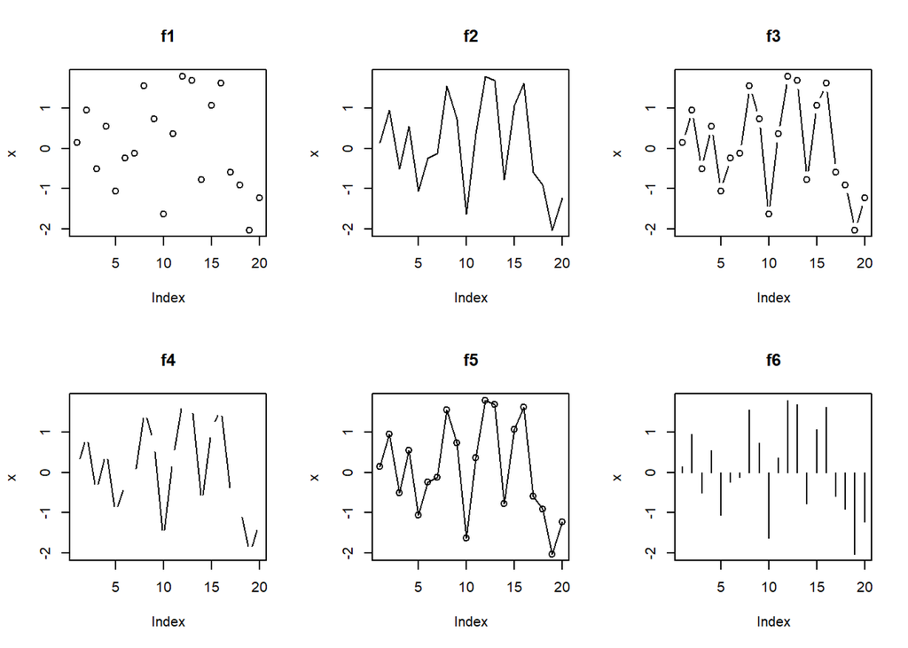

```r
# plot(): type 參數的設定
 x <- rnorm(20)
 par(mfrow=c(2,3))  # 以下有6個圖形，排列成 2 x 3
 plot(x, type="p", main="f1")
 plot(x, type="l", main="f2")
 plot(x, type="b", main="f3")
 plot(x, type="c", main="f4")
 plot(x, type="o", main="f5")
 plot(x, type="h", main="f6")
```

### Plot (2)

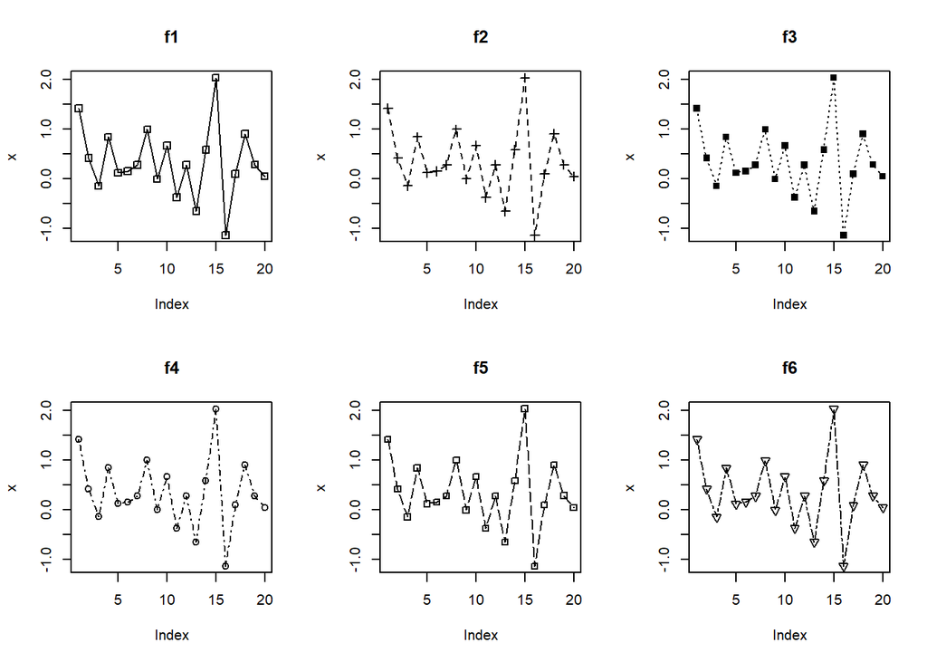

```r
# plot(): pch 和 lty 參數的設定
x <- rnorm(20)
par(mfrow=c(2,3))
# pch 的值為 0~25，呈現不同點的型態
# lty 的值為 1~6，呈現不同的線條

plot(x, type="o", main="f1", pch=0, lty=1)
plot(x, type="o", main="f2", pch=3, lty=2)
plot(x, type="o", main="f3", pch=15, lty=3)
plot(x, type="o", main="f4", pch=21, lty=4)
plot(x, type="o", main="f5", pch=22, lty=5)
plot(x, type="o", main="f6", pch=25, lty=6)
```

### Plot (3)

```r
# plot(): color 和 lwd 參數的設定
 x <- rnorm(20)
 par(mfrow=c(2,3)) > # col 可以改變座標軸(col.axi), X與Y軸說明文字 (col.lab)
 # 主標題 (col.main)和 副標題 (col.sub)的顏色
 # R常用的顏色編號可直接用1~6
 plot(x, type="o", main="f1", pch=0, lty=1)
```

```
## logical(0)
```

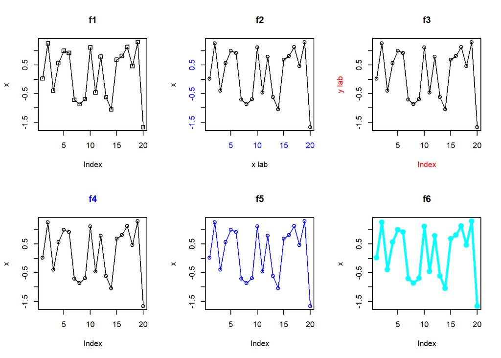

```r
 plot(x, type="o", main="f2", xlab="x lab", col.axis=4)
 plot(x, type="o", main="f3", ylab="y lab", col.lab="red")
 plot(x, type="o", main="f4", col.main=4)
 plot(x, type="o", main="f5", col=4)
 plot(x, type="o", main="f6", col=5, lwd=3)
```

### Plot (4)

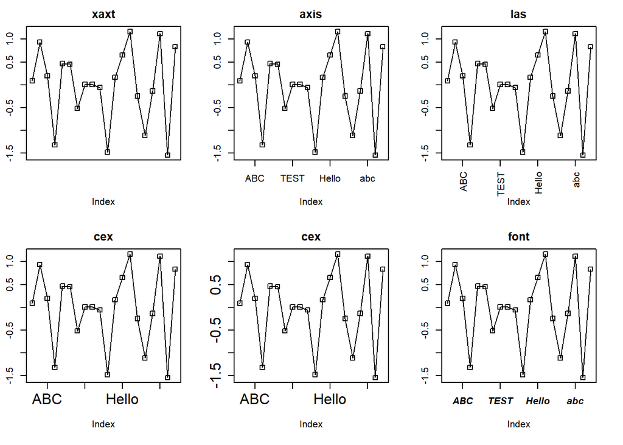

```r
 # mai, xaxt, axis, las, cex, font 參數
 x <- rnorm(20)  # 從常態分配N(0,1)中隨機抽出20筆資料
 par(mfrow=c(2,3), mai=c(0.7,0.3,0.3,0.3)) # 以下有六個圖形，排列成 2 x 3
 # mai 參數可以設定小圖之間的距離
 # xaxt="n" 表示x軸將有使用者自行設定，若無設定，則為空白
 plot(x, type="o", main="xaxt", pch=0, lty=1, xaxt="n")
 # 加上 axis(1, at=..., label=,...)用以設定x軸
 plot(x, type="o", main="axis", pch=0, lty=1, xaxt="n")
 axis(1, at=seq(3,20,by=5), label=c("ABC", "TEST", "Hello", "abc"))
 # las=1 (預設值) 座標值平行，las=2 與座標軸垂直
 plot(x, type="o", main="las", pch=0, lty=1, xaxt="n")
 axis(1, at=seq(3,20,by=5), label=c("ABC", "TEST", "Hello", "abc"), las=2)
 # cex: 設定文字大小是標準字體的幾倍大
 plot(x, type="o", main="cex", pch=0, lty=1, xaxt="n")
 axis(1, at=seq(3,20,by=5), label=c("ABC", "TEST", "Hello", "abc"), cex.axis=1.5)
 plot(x, type="o", main="cex", pch=0, lty=1, xaxt="n", yaxt="n")
 axis(1, at=seq(3,20,by=5), label=c("ABC", "TEST", "Hello", "abc"), cex.axis=1.5)
 axis(2, cex.axis=1.5)
 # font: 使用文字字體的類型，1表示正常，2為粗體，3為斜體，4為斜粗體
 plot(x, type="o", main="font", pch=0, lty=1, xaxt="n")
 axis(1, at=seq(3,20,by=5), label=c("ABC", "TEST", "Hello", "abc"), font=4)
```

### Plot (5)

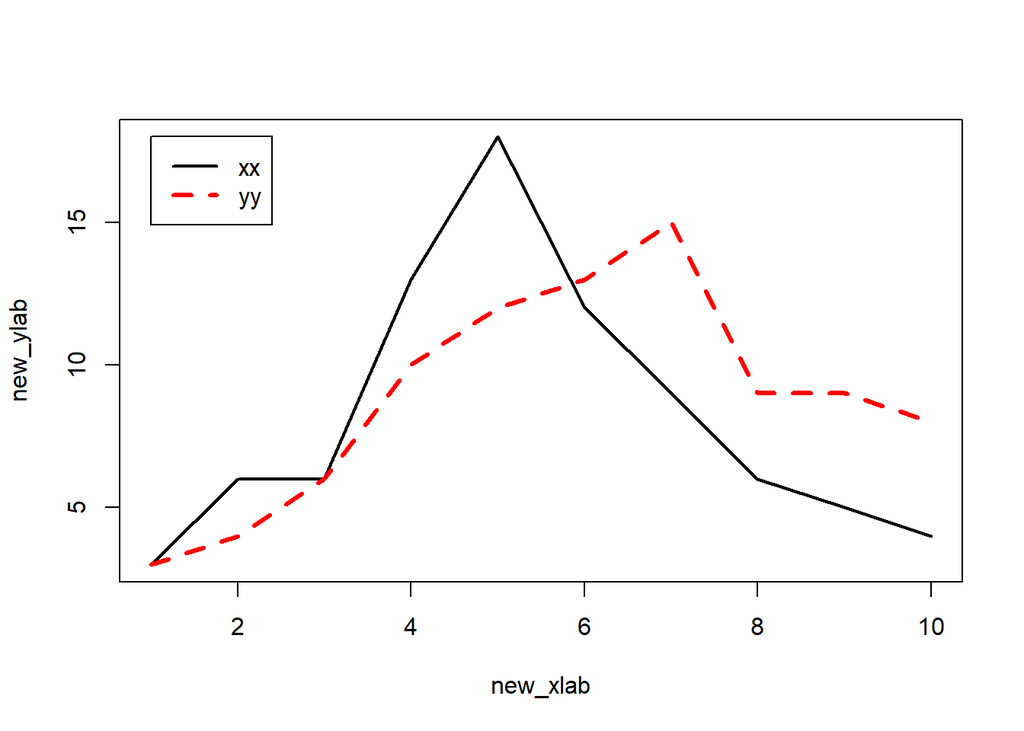

```r
xx <- c(3, 6, 6, 13, 18, 12, 9, 6, 5, 4)
yy <- c(3, 4, 6, 10, 12, 13, 15, 9, 9, 8)
plot(xx, col=1, type="l", lty=1, lwd=2, xlab="new_xlab", ylab="new_ylab")
lines(yy, col=2, type="l", lty=2, lwd=3)
legend(1, 18, c("xx","yy"), col=c(1, 2), lty=c(1, 2), lwd=c(2,3))
```

## ———————————————————————————————–